# Fundermentals of R

Advanced R - 1.0 Data Cleaning

Prepared By Clinton Moshe Mwachia

2023-07-06

## Introduction

Data cleaning is an essential step in the data analysis process. It involves identifying and handling various data issues, such as missing values, duplicates, incorrect data types. In this lesson, we will cover techniques for cleaning and preparing your data in R.

# Missing Data

## Checking Missing Data

Missing data can occur when certain observations or variables have incomplete or unknown values. It is crucial to identify and handle missing data appropriately to avoid biased analysis. R provides functions to detect and handle missing values, such as `is.na()` and `complete.cases()`.

Code Example:

```r
# clean data
data <- data.frame(
  x = c(1, 2, 3, 4, 5),
  y = c("a", "b", "c", "d", "e")
)

# Checking for missing values
is.na(data)
```

```
##          x     y
## [1,] FALSE FALSE
## [2,] FALSE FALSE
## [3,] FALSE FALSE
## [4,] FALSE FALSE
## [5,] FALSE FALSE
```

```r
# data with NA values
data2 <- data.frame(
  a = c(100, 203, 340, 450, 550),
  x = c(1, 2, 3, 4, NA),
  y = c(80, 83, NA, 90, 34),
  z = c(10, 20, 30, 40, 50)
)

# Checking for missing values
is.na(data2)
```

```
##          a     x     y     z
## [1,] FALSE FALSE FALSE FALSE
## [2,] FALSE FALSE FALSE FALSE
## [3,] FALSE FALSE  TRUE FALSE
## [4,] FALSE FALSE FALSE FALSE
## [5,] FALSE  TRUE FALSE FALSE
```

## Handling Missing Data

Handling missing data or NA values is crucial in data analysis to ensure accurate and reliable results. In R, there are several ways to handle missing data. Here are some common techniques

### Removing Missing Data

One approach is to remove the rows or columns with missing data from the dataset. This method is suitable when the missing data is random and does not significantly impact the overall analysis.

```r
# Removing rows with missing values
clean_data = na.omit(data2)

# Removing columns with missing values
clean_data2 <- data2[, -c(2,3)]

is.na(clean_data)
```

```
##       a     x     y     z
## 1 FALSE FALSE FALSE FALSE
## 2 FALSE FALSE FALSE FALSE
## 4 FALSE FALSE FALSE FALSE
```

```r
is.na(clean_data2)
```

```
##          a     z
## [1,] FALSE FALSE
## [2,] FALSE FALSE
## [3,] FALSE FALSE
## [4,] FALSE FALSE
## [5,] FALSE FALSE
```

### Imputing Missing Data with mean/median

Imputation involves replacing missing values with estimated or plausible values. This approach helps retain the complete dataset while minimizing the impact of missing data.

```r
data2_copy = data2
# Imputing missing values with mean
data2_copy$x <- ifelse(is.na(data2_copy$x),
                       mean(data2_copy$x, na.rm = TRUE), data2_copy$x)

data2_copy$y <- ifelse(is.na(data2_copy$y),
                       mean(data2_copy$y, na.rm = TRUE), data2_copy$y)

is.na(data2_copy)
```

```
##          a     x     y     z
## [1,] FALSE FALSE FALSE FALSE
## [2,] FALSE FALSE FALSE FALSE
## [3,] FALSE FALSE FALSE FALSE
## [4,] FALSE FALSE FALSE FALSE
## [5,] FALSE FALSE FALSE FALSE
```

# Duplicate Data

Duplicate data refers to observations that have identical values across multiple variables. It is important to identify and remove duplicates to avoid skewed analysis results. R offers functions like `duplicated()` and `unique()` for checking and handling duplicate data.

## Checking Duplicate Data

```r
# Creating a sample data frame with duplicate values
data_dup <- data.frame(
  x = c(1, 2, 3, 4, 2),
  y = c("a", "b", "c", "d", "b"),
  z = c(1, 2, 3, 4, 2)
)

# Checking for duplicate rows
any_dup <- any(duplicated(data_dup))
any_dup
```

```
## [1] TRUE
```

## Count Duplicate rows

Sometimes, it may be useful to identify and count the number of duplicate rows in a dataset without removing them. This can help gain insights into the frequency of duplicate observations.

```r
# Counting duplicate rows
dup_count <- table(duplicated(data_dup))
dup_count
```

```
##
## FALSE  TRUE
##     4     1
```

## Remove Duplicate Data

```r
# get unique data
unique_data <- unique(data_dup)

any(duplicated(unique_data))
```

```
## [1] FALSE
```

These techniques help in handling duplicate data in R. It is important to carefully consider the nature of the data and the specific analysis requirements when deciding on the appropriate method for handling duplicates.

# Dropping Columns/Rows

Removing unnecessary columns or rows in R involves excluding specific variables or observations from a dataset. Some common techniques for removing unnecessary columns or rows include: -

## Removing Columns by Index

```r
# make a copy of duplicated data frame
data_dup_copy = data_dup

# Removing columns 1
new_data_dup_copy <- data_dup_copy[, -1]

new_data_dup_copy
```

```
##   y z
## 1 a 1
## 2 b 2
## 3 c 3
## 4 d 4
## 5 b 2
```

## Removing Columns by Name

```r
# make a copy of duplicated data frame
data_dup_copy = data_dup

# Removing columns 1
new_data_dup_copy <- data_dup_copy[, c("y","z")]

new_data_dup_copy
```

```
##   y z
## 1 a 1
## 2 b 2
## 3 c 3
## 4 d 4
## 5 b 2
```

We can simplify the above process by using a package called `dplyr` as shown below

```r
library(dplyr) # provides the select function
library(magrittr) # for piping operator

# remove column x
new_data_dup_copy =  data_dup %>%
  select(-x)

new_data_dup_copy
```

```
##   y z
## 1 a 1
## 2 b 2
## 3 c 3
## 4 d 4
## 5 b 2
```

## Removing Rows with NA Values

```r
# Removing rows with NA values
data2[complete.cases(data2), ]
```

```
##     a x  y  z
## 1 100 1 80 10
## 2 203 2 83 20
## 4 450 4 90 40
```

## Removing Rows by Index

```r
# Removing row 1
data2[-1,]
```

```
##     a  x  y  z
## 2 203  2 83 20
## 3 340  3 NA 30
## 4 450  4 90 40
## 5 550 NA 34 50
```

```r
# Removing row 1, and 3
data2[-c(1,3),]
```

```
##     a  x  y  z
## 2 203  2 83 20
## 4 450  4 90 40
## 5 550 NA 34 50
```

```r
# Removing row 1 through 3
data2[-c(1:3),]
```

```
##     a  x  y  z
## 4 450  4 90 40
## 5 550 NA 34 50
```

## Removing Duplicate Rows

```r
unique(data2)
```

```
##     a  x  y  z
## 1 100  1 80 10
## 2 203  2 83 20
## 3 340  3 NA 30
## 4 450  4 90 40
## 5 550 NA 34 50
```

## Filter Rows by condition

```r
# filter data with x = 1
data2[data2$x == 1,]
```

```
##      a  x  y  z
## 1  100  1 80 10
## NA  NA NA NA NA
```

```r
# filter data with x > 1
data2[data2$x > 1,]
```

```
##      a  x  y  z
## 2  203  2 83 20
## 3  340  3 NA 30
## 4  450  4 90 40
## NA  NA NA NA NA
```

# outliers

Outlier is an observation or data point that significantly deviates from the overall pattern or distribution of the dataset. Outliers are extreme values that lie far away from the majority of the data points and may have a disproportionate influence on statistical measures and analyses.

Outliers can arise due to various reasons, such as data entry errors, measurement errors, natural variations, or rare events. They can distort statistical measures, impact the assumptions of certain analysis techniques, and affect the accuracy and reliability of data analysis results.

Identifying and understanding outliers is important because they can provide valuable insights into the data, highlight anomalies, or indicate potential data quality issues. Outliers can either be univariate (deviation in a single variable) or multivariate (deviation in multiple variables simultaneously).

It is essential to consider the context and domain knowledge when determining whether an observation is an outlier. Outliers may be legitimate data points that represent unusual or significant phenomena, or they may be data errors that need to be addressed during data cleaning and analysis.

Various statistical techniques and visual tools, such as boxplots, z-scores, scatter plots, and data visualization methods, are used to detect and analyze outliers in a dataset. The decision to handle or exclude outliers depends on the specific goals of the analysis, the nature of the data, and the impact of the outliers on the overall analysis results.

## Outlier Detection

### Using Box-Plots

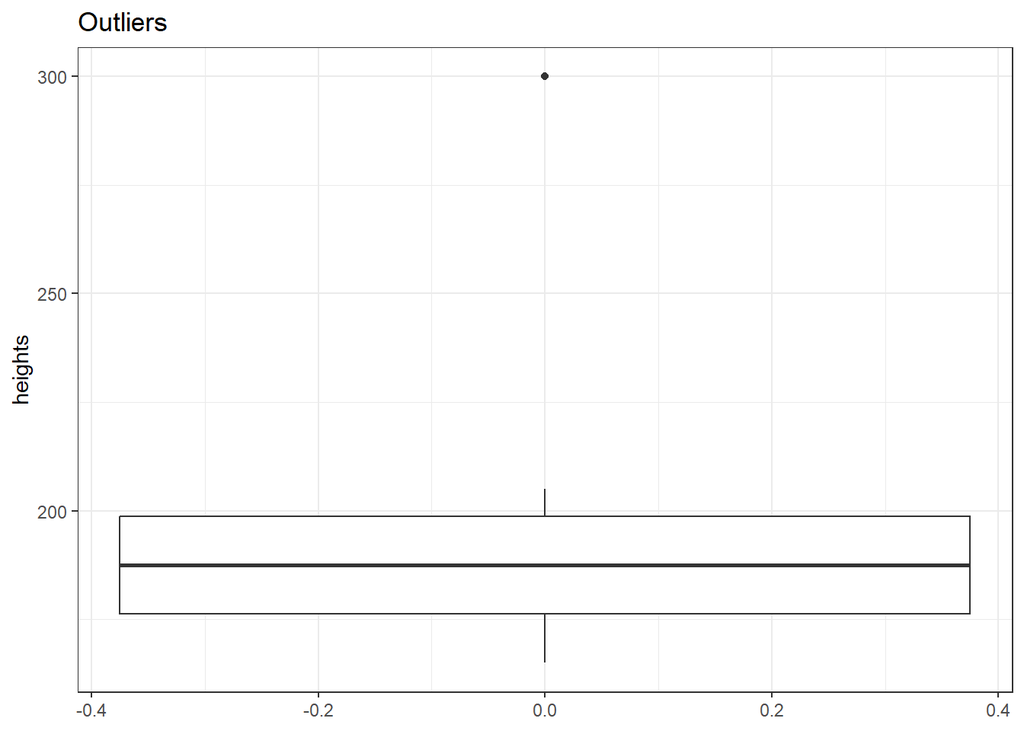

```r
# loading required library
library(ggplot2) # for plots
# sample data
df = data.frame(
  heights = c(165, 170, 175, 180, 185, 190, 195, 200, 205,300)
)

# box-plot
df %>%
  ggplot(aes(y=heights)) +
  geom_boxplot() +
  theme_bw() +
  ggtitle("Outliers")
```

By examining the boxplot, outliers can be identified as points that are significantly outside the whiskers of the boxplot. In this case, the height value of 300 appears to be an outlier.

### Using Z-Scores

Z-scores measure how many standard deviations an observation is from the mean. Observations with a z-score greater than a certain threshold (e.g., 2 or 3) can be considered outliers. R provides the scale() function to calculate z-scores.

```r
# Calculating z-scores
z_scores <- scale(df$heights)
z_scores
```

```
##              [,1]
##  [1,] -0.81627952
##  [2,] -0.68671134
##  [3,] -0.55714316
##  [4,] -0.42757499
##  [5,] -0.29800681
##  [6,] -0.16843863
##  [7,] -0.03887045
##  [8,]  0.09069772
##  [9,]  0.22026590
## [10,]  2.68206128
## attr(,"scaled:center")
## [1] 196.5
## attr(,"scaled:scale")
## [1] 38.58972
```

```r
# Identifying outliers
outliers <- which(abs(z_scores) > 2)
outliers
```

```
## [1] 10
```

We have looked at ways of identifying outlier, on your own time, find all the ways you can use to handle them and give its pros and cons.

HURRAY! THE END OF THE LESSON, PROCEED TO THE ASSIGNEMENT.